# Лабораторная работа 9

### Упражнение 9.1

В разделе «Нарастающая сумма» в методических материалах было отмечено, что данные примеры работают только с периодическими сигналами. Проверим это, подав вместо пилообразного сигнала данные с биржи о компании Facebook:

```python
import numpy as np
import matplotlib.pyplot as plt
import pandas as pd
from thinkdsp import *
```

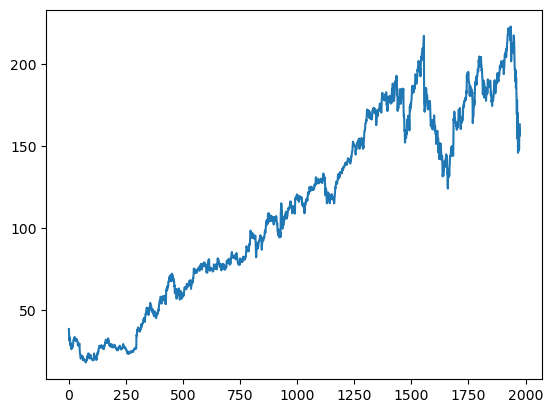

```python
df = pd.read_csv('FB_2.csv', header=0, parse_dates=[0])
ys = df['Close']
if len(ys) % 2:
    ys = ys[:-1]

in_wave = Wave(ys, framerate=1)
in_wave.plot()
```

Также построим спектр волны

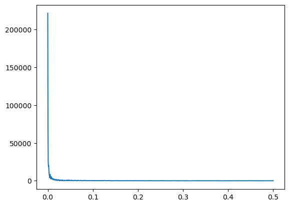

```python
in_spectrum = in_wave.make_spectrum()
in_spectrum.plot()
```

Теперь построим нарастающую сумму сигнала, нарастающая сумма - аппроксимация интегрирования.

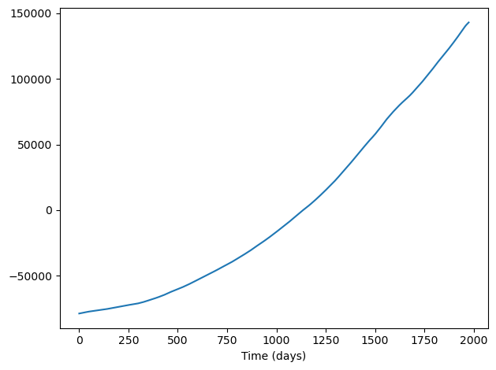

```python
out_wave = in_wave.cumsum()
out_wave.unbias()
out_wave.plot()
decorate(xlabel='Time (days)')
```

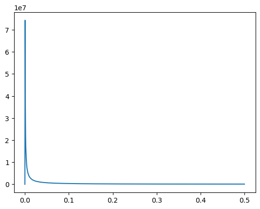

```python
out_spectrum = out_wave.make_spectrum()
out_spectrum.plot()
```

Сравнивая с графиком нарастающей суммы, можем заметить, что график не циклический. Это связано с сигналом - в примере используется циклический пилообразный сигнал.

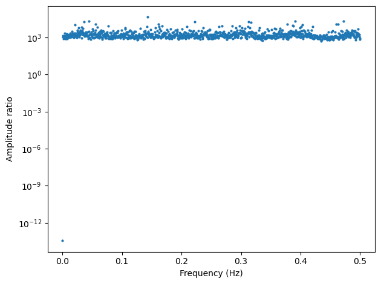

```python
in_spectrum = in_wave.make_spectrum()
ratio_spectrum = out_spectrum.ratio(in_spectrum, thresh=1)
ratio_spectrum.plot(marker='.', ms=4, ls='')

decorate(xlabel='Frequency (Hz)',
         ylabel='Amplitude ratio',
         yscale='log')
```

Чтобы наблюдать корректное отношение между спектрами входного и выходного сигналов, нормализуем их.

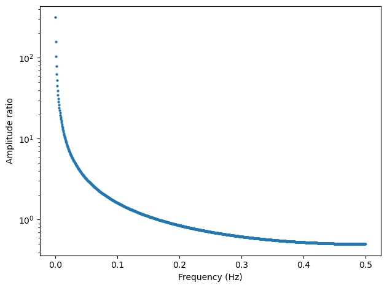

```python
in_wave = Wave(ys, framerate=1)
in_wave.unbias()
out_wave = in_wave.cumsum()
out_spectrum = out_wave.make_spectrum()
in_spectrum = in_wave.make_spectrum()
ratio_spectrum = out_spectrum.ratio(in_spectrum, thresh=1)

ratio_spectrum.plot(marker='.', ms=4, ls='')

decorate(xlabel='Frequency (Hz)',
        ylabel='Amplitude ratio',
         yscale='log')
```

Также мы можем сравнить вычисленные отношения с фильтром накапливающей суммы. Чтобы получить фильтр накапливающей суммы, можем вычислить дифференциальный фильтр и взять обратное от него

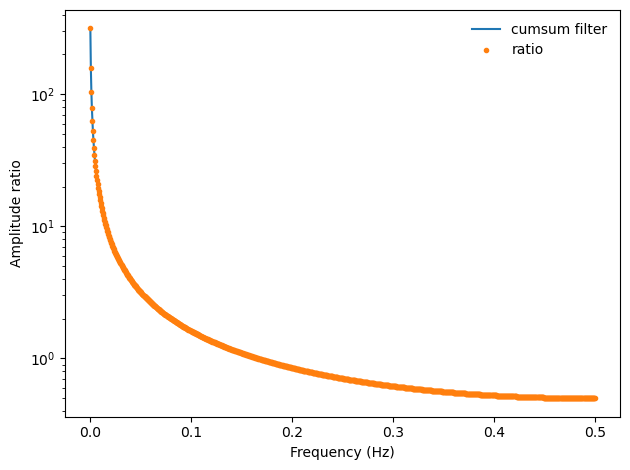

```python
diff_window = np.array([1.0, -1.0])
padded = zero_pad(diff_window, len(in_wave))
diff_wave = Wave(padded, framerate=in_wave.framerate)
diff_filter = diff_wave.make_spectrum()

cumsum_filter = diff_filter.copy()
cumsum_filter.hs[1:] = 1 / cumsum_filter.hs[1:]
cumsum_filter.hs[0] = np.inf

cumsum_filter.plot(label='cumsum filter')
ratio_spectrum.plot(marker='.', label='ratio', ls='')

decorate(xlabel='Frequency (Hz)',
         ylabel='Amplitude ratio',
         yscale='log')
```

Также проверим теорему о свертке, применив фильтр в частотной области

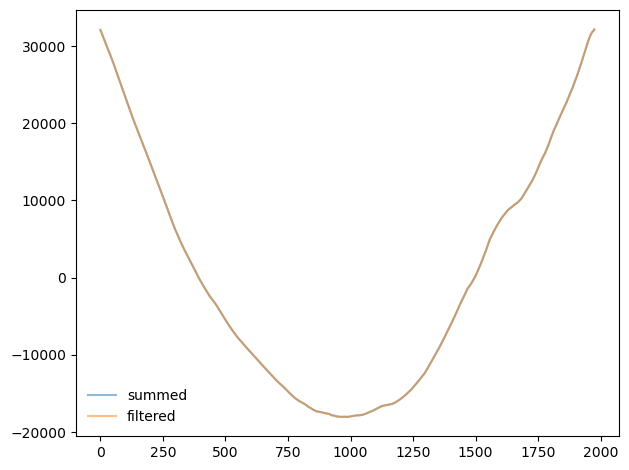

```python
in_wave = Wave(ys, framerate=1)
in_wave.unbias()
out_wave = in_wave.cumsum()
out_wave.unbias()

out_wave.plot(label='summed', alpha=0.5)
cumsum_filter.hs[0] = 0
out_wave2 = (in_spectrum * cumsum_filter).make_wave()
out_wave2.unbias()
out_wave2.plot(label='filtered', alpha=0.5)
decorate()
```

Как мы можем заметить полученные кривые совпадают с точностью до погрешности вычислений. Таким образом, можем сделать вывод, что для реальных сигналов метод работает корректно при условии, что сигналы нормализованы

### Упражнение 9.2

> В этом упражнении изучается влияние `diff` и `differentiate` на сигнал. Создайте треугольный сигнал и напечатайте его. Примените `diff` к сигналу и напечатайте результат. Вычислите спектр треугольного сигнала, примените `differentiate` и напечатайте результат. Преобразуйте спектр обратно в сигнал и напечатайте его. Есть ли различия в воздействии `cumsum` и `integrate` на этот сигнал

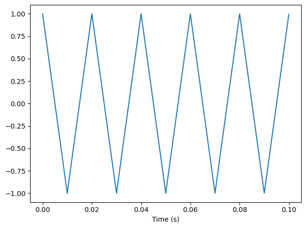

```python
in_wave = TriangleSignal(freq=50).make_wave(duration=0.1, framerate=44100)
in_wave.plot()
decorate(xlabel='Time (s)')
```

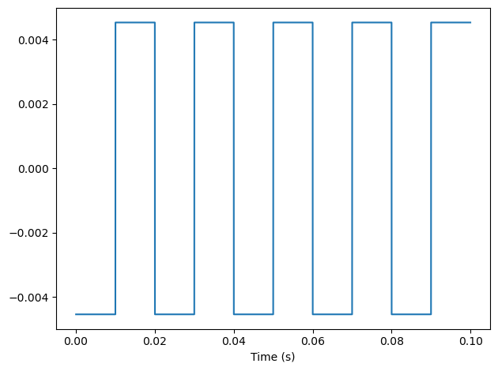

```python
out_wave = in_wave.diff()
out_wave.plot()
decorate(xlabel='Time (s)')
```

Результатом взятия производной от треугльного сигнала является прямоугольный сигнал, так как треугольный сигнал равномерно возрастает и спадает - это соответствует горизонтальным линиям прямоугольного сигнала.

Теперь применим `differentiate` к спектру треугольного сигнала

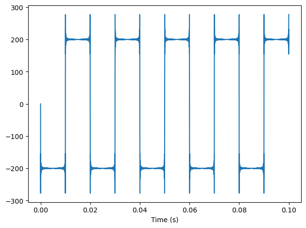

```python
out_wave2 = in_wave.make_spectrum().differentiate().make_wave()
out_wave2.plot()
decorate(xlabel='Time (s)')
```

Полученный сигнал совпадает с прямоугольным, но мы получаем звон в местах перехода сигнала с одного уровня на другой. Это связано с тем, что производная треугольного сигнала не определена в местах перегиба

### Упражнение 9.3

> В данном упражнении изучается влияние `cumsum` и `integrate` на сигнал. Создайте прямоугоьлный сигнал и напечатайте его. Примените `cumsum` и напечатайте результат. Преобразуйте спектр прямоугольного сигнала, примените `integrate` и напечатайте результат. Преобразуйте спектр обратно в сигнал и напечатайте его. Есть ли различия в воздействии `cumsum` и `integrate` на этот сигнал?

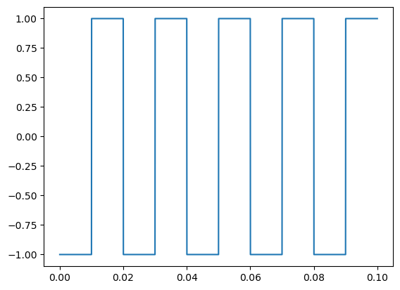

```python
in_wave = SquareSignal(freq=50).make_wave(duration=0.1, framerate=44100)
in_wave.plot()
```

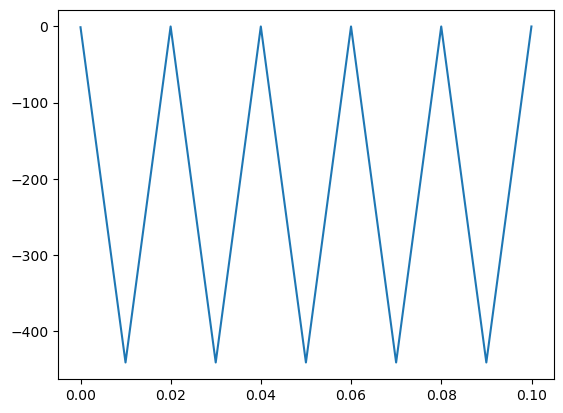

```python
out_wave = in_wave.cumsum()
out_wave.plot()
```

Как и ожидалось при взятии накопленной сумма от прямоугольного сигнала, получаем треугольный. Это было рассмотрено в предыдущем упражнении

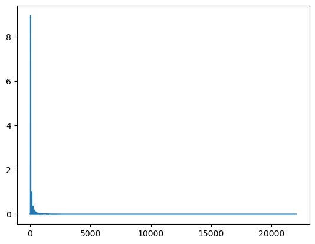

```python
sq_spectrum_int = in_wave.make_spectrum().integrate()
sq_spectrum_int.plot()
```

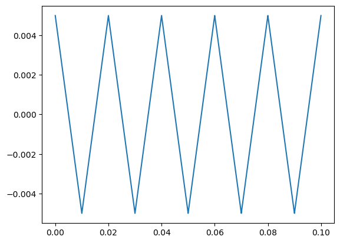

```python
sq_spectrum_int.hs[0] = 0
out_wave2 = sq_spectrum_int.make_wave()
out_wave2.plot()
```

Интегрирование спектра сигнала также дает нам треугольный сигнал, но амплитуды очень сильно отличаются

Для сравнения накапливающей суммы и интегрирования нормализуем оба сигнала

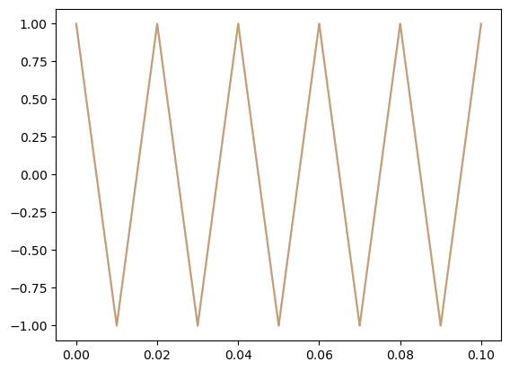

```python
out_wave.unbias()
out_wave.normalize()
out_wave2.normalize()
out_wave.plot(alpha=0.5)
out_wave2.plot(alpha=0.5)
```

Полученные сигналы идентичны с хорошей точностью

```python
out_wave.max_diff(out_wave2)
```

```
2.7755575615628914e-17
```

### Упражнение 9.4

> Создайте пилообразный сигнал, вычислите его спектр, а затем дважды примените `integrate`. Напечатайте результирующий сигнал и его спектр. Какова математическая форма сигнала? Почему он напоминает синусоиду?

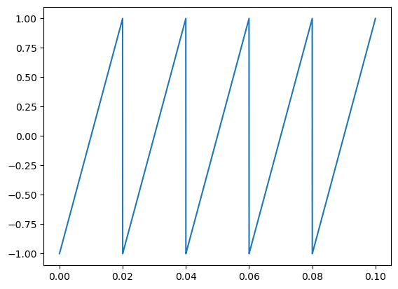

```python
in_wave = SawtoothSignal(freq=50).make_wave(duration=0.1, framerate=44100)
in_wave.plot()
```

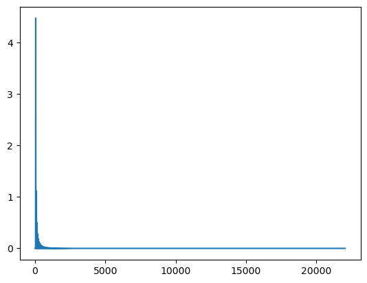

```python
in_spectrum = in_wave.make_spectrum().integrate()
in_spectrum.plot()
```

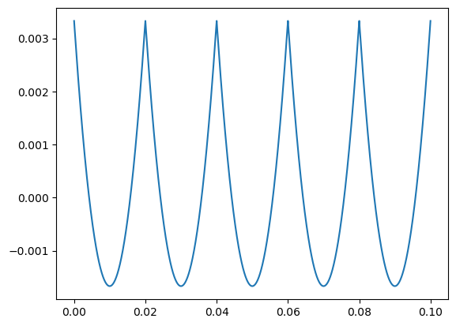

```python
in_spectrum.hs[0] = 0
out_wave = in_spectrum.make_wave()
out_wave.unbias()
out_wave.plot()
```

Первый интеграл от пилообразного сигнала дает сигнал, который состоит из парабол. Появление параболы монжо объяснить тем, что пилообразный сигнал - повторяющиеся прямые, которые можно описать уравнением $y=x$, если взять интеграл, то получим $y=\frac{x^2}{2}$. Квадрат дает параболу

При повторном взятии интеграла получим кубическую кривую, ее появление можно также объяснить взятием интегала.

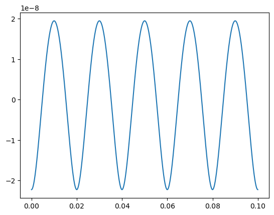

```python
in_spectrum = in_spectrum.integrate()
in_spectrum.hs[0] = 0
out_wave = in_spectrum.make_wave()
out_wave.plot()
```

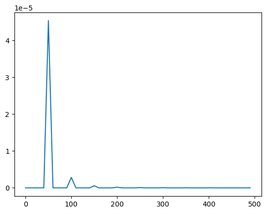

```python
out_wave.make_spectrum().plot(high=500)
```

### Упражнение 9.5

> Создайте `CubicSignal`, определенный в `thinkdsp`. Вычислите вторую разность, дважды применив `diff`. Как выглядит результат? Вычислите вторую вторую производную, дважды применив `differentiate` к спектру. Похожи ли результаты?  
> Распечатайте фильтры, соответствующте второй разности и второй производной, и сравните их.

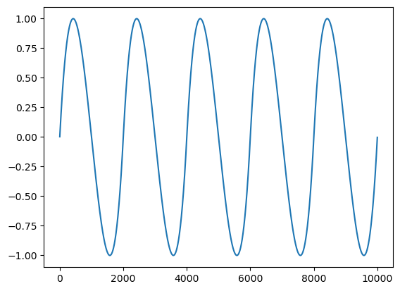

```python
in_wave = CubicSignal(freq=0.0005).make_wave(duration=10000, framerate=1)
in_wave.plot()
```

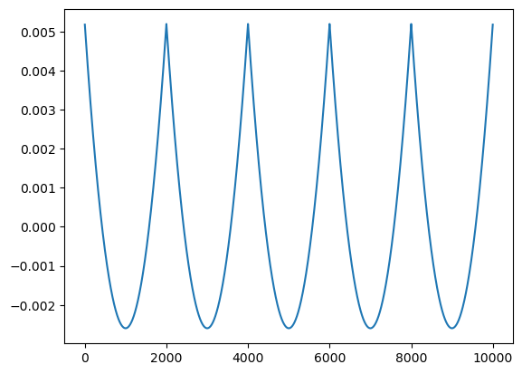

```python
out_wave = in_wave.diff()
out_wave.plot()
```

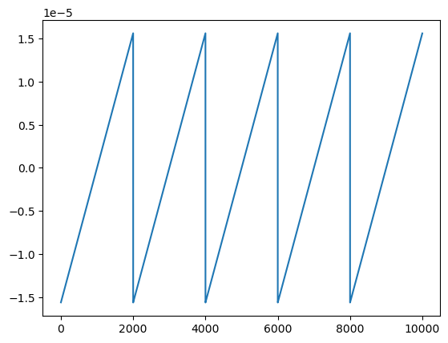

```python
out_wave = out_wave.diff()
out_wave.plot()
```

Полученные результаты подтверждают, что дифференциирование обратно интегрированию. Принцип описан в предыдущем упражнении

При двойном дифференциировании спектра получаем звон у волны в местах, где производная параболы не определена

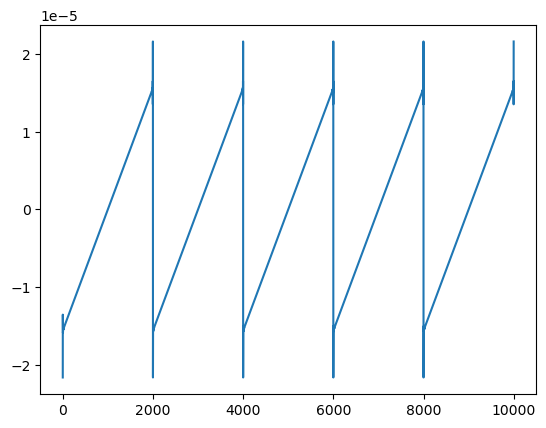

```python
spectrum = in_wave.make_spectrum().differentiate().differentiate()
out_wave2 = spectrum.make_wave()
out_wave2.plot()
```

Для нахождения фильтра, который соответствует второй конечной разности, можем вычислить фильтр окна, которое соответствует второй конечной разности

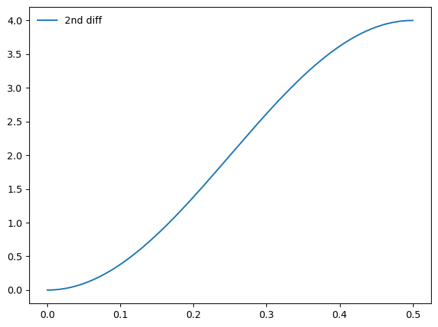

```python
diff_window = np.array([-1.0, 2.0, -1.0])
padded = zero_pad(diff_window, len(in_wave))
diff_wave = Wave(padded, framerate=in_wave.framerate)
diff_filter = diff_wave.make_spectrum()
diff_filter.plot(label='2nd diff')
decorate()
```

Для нахождения фильтра второй производной, можно рассчитать фильтр первой производной и возвести его в квадрат

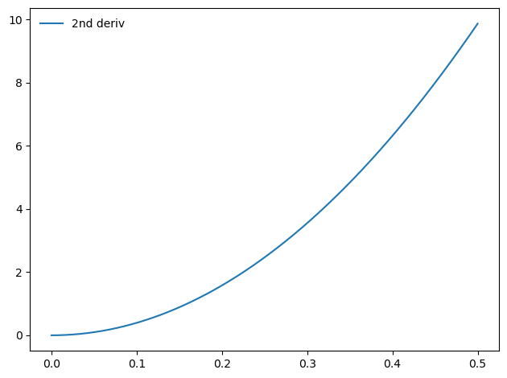

```python
deriv_filter = in_wave.make_spectrum()
deriv_filter.hs = (np.pi * 2 * 1j * deriv_filter.fs)**2
deriv_filter.plot(label='2nd deriv')

decorate()
```

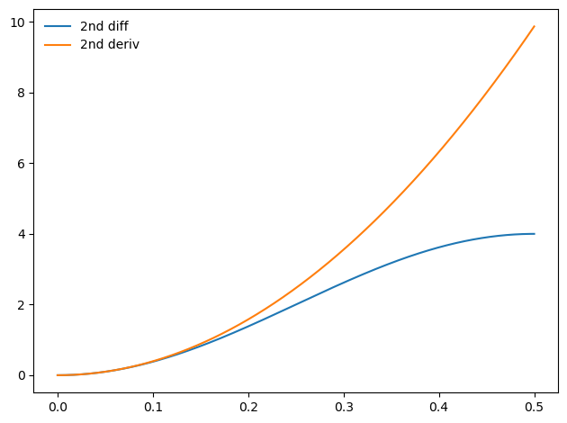

```python
diff_filter.plot(label='2nd diff')
deriv_filter.plot(label='2nd deriv')
decorate()
```